# Financial and Estate Planning Literacy: Item Validation and Categorical CFA

Author

Jamie C. Lee

Published

August 11, 2026

## Summary

In this document, we perform a set of analyses that test whether **estate planning literacy (EPL)** is an empirically distinct construct from **financial literacy (FL)** (Fernandes et al. 2014).

### Document Outline

[output not shown]

**NoteNote**

`fin_8` is **dropped from the analyses**: I tried different ways of coding the correct response, but none of them discriminated between high and low scorers. All analyses reported in this document include only the **12 FL items** and **12 EPL items**, 24 total.

### 0.0.1 Overview of Results

**Question 1 — do the items map onto distinguishable factors? (Section 5)** Yes. A two-factor model that separates financial literacy (FL) from estate planning literacy (EPL) fits significantly better than a one-factor general-literacy model (scaled $\Delta\chi^2$(1) = 33.6, *p* < .001). Splitting EPL further into financial-consequence and legal/administrative dimensions improves fit again (scaled $\Delta\chi^2$(2) = 20.7, *p* < .001). Of the models evaluated, the three-factor model fits best (CFI = 0.966, RMSEA = 0.026). Therefore, the three content domains are empirically distinguishable: treating all 24 items as indicators of a single undifferentiated factor misses meaningful structure in the data.

**Question 2 — do the blocks measure distinct abilities of their own? (Section 6)** Not necessarily. Although the three factors are distinguishable, they are also strongly correlated (0.63–0.77). The better fit of the three-factor model tells us that items within the same domain share additional covariance, but it does not tell us whether that covariance reflects a substantial domain-specific ability or is mostly part of a broader ability shared across all items.

A bifactor model separates these two sources of variance. It estimates a general (literacy) factor shared by all 24 items while simultaneously asking whether items within FL, EPL-Fin, and EPL-Legal still share meaningful variance after that general factor is accounted for. Roughly two-thirds of the common variance is attributable to the general factor. FL and EPL-Legal retain only modest domain-specific variance, while EPL-Fin retains essentially none: its specific factor cannot be estimated reliably, indicating that the three EPL-Fin items cohere primarily because of what they share with the broader general factor rather than because they measure a distinct EPL-Fin ability.

**Practical upshot.** The results support retaining the three-factor structure as the best description of the item covariance, but they provide much weaker support for interpreting the three domains as separate, reliable subscales. The measure is therefore best scored primarily with a **total score rather than separate subscores**. The three-item EPL-Fin subscale, in particular, should not be interpreted on its own.

# 1 Bot Exclusion Checks

Two behavioral indicators, both adapted from Zhang et al., are used to exclude potential bots.

## 1.1 The Two Detectors

**Prompt injection.** Participants select the apple juice brands they buy regularly. Hidden within the response-option text is an instruction, displayed in white font against a white background, directing participants to select “Golden Grove” - a fictitious brand. Because the instruction is visually undetectable to a human respondent, human participants would not be expected to follow it.

**Reverse shibboleth.** Participants estimated the calories, carbohydrates, fat, and protein in an 8-oz glass of apple juice without looking up the information. Individuals are flagged as potential bots if they demonstrate “superhuman knowledge,” which is defined as having **all four** of their responses fall within a small range around the true values: 105–120 cal, 26–29 g carbs, 0–0.5 g fat, 0–1 g protein.

Table 1. Bot Exclusions (Full Sample, N = 399)

| Criterion | N | % of full sample |
| --- | --- | --- |
| Selected "Golden Grove" (prompt injection) | 15 | 3.8 |
| All four nutrition estimates in band (shibboleth) | 15 | 3.8 |
| Flagged by both | 3 | 0.8 |
| Flagged by at least one — excluded | 27 | 6.8 |
| Retained — analysis sample | 372 | 93.2 |

Table 2. Reverse-Shibboleth Accuracy Breakdown by Item

| Component | N in band | % |
| --- | --- | --- |
| Calories (105-120) | 60 | 15.0 |
| Carbohydrates (26-29 g) | 22 | 5.5 |
| Fat (0-0.5 g) | 217 | 54.4 |
| Protein (0-1 g) | 238 | 59.6 |
| All four simultaneously | 15 | 3.8 |

Fat and protein are relatively easy to get correct, because both true values sit near zero and “0” is a common lay-guess. Calories and carbohydrates are more the discriminating items.

## 1.2 Validation Checks on the Bot Detection Measures

Survey-taking bots may vary considerably in sophistication. At one extreme, simple bots may respond randomly or according to basic rules, producing low-quality or internally inconsistent answers. At the other extreme, more sophisticated bots may use large language models or other generative AI tools to produce responses that resemble those of attentive human participants. Intermediate cases may rely on scripted heuristics, patterned responding, or selective use of automated tools.

If these different forms of automation are present in our sample, bot responses may appear at both extremes of performance on the literacy items: unsophisticated bots may perform unusually poorly (if they are responding randomly), whereas more sophisticated AI-assisted bots may perform unusually well. The exclusion patterns reported below are consistent with this possibility, though they do not by themselves establish that flagged responses were generated by bots.

Table 3. Score Band by Bot-Flag Rate (Full Sample, N = 399)

| Combined score | N | Median duration (min) | Mean items blank | N flagged | % flagged |
| --- | --- | --- | --- | --- | --- |
| 0-9 | 38 | 17.3 | 7.0 | 3 | 7.9 |
| 10-13 | 81 | 18.1 | 3.3 | 1 | 1.2 |
| 14-17 | 137 | 18.5 | 1.9 | 2 | 1.5 |
| 18-22 | 112 | 20.0 | 0.6 | 8 | 7.1 |
| 23-24 | 31 | 24.8 | 0.0 | 13 | 41.9 |

Table 4. Do Top Scorers (23+ of 24) Trip the Detectors?

| Detector | Top band | Everyone else | Odds ratio | 95% CI | p |
| --- | --- | --- | --- | --- | --- |
| Prompt injection | 4 / 31 (12.9%) | 11 / 368 (3.0%) | 4.8 | [1.0, 17.6] | 0.022 |
| Reverse shibboleth | 11 / 31 (35.5%) | 4 / 368 (1.1%) | 48.5 | [13.0, 226.8] | < .001 |
| Either | 13 / 31 (41.9%) | 14 / 368 (3.8%) | 17.9 | [6.7, 48.5] | < .001 |

Fisher's exact tests. Odds ratios are conditional MLEs.

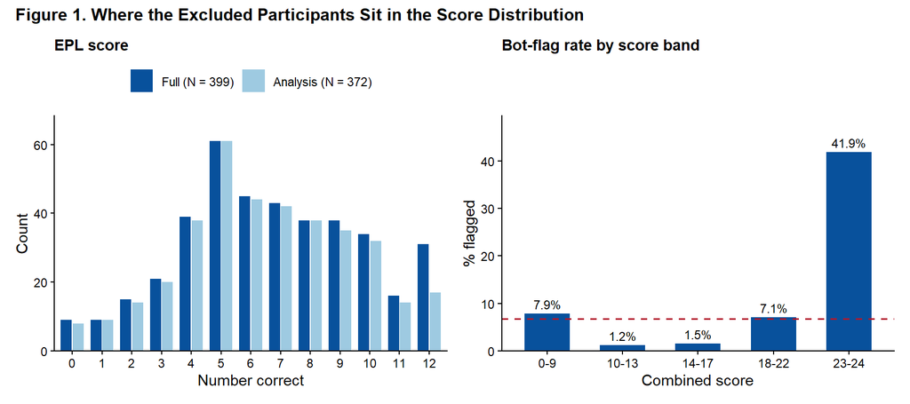

The flag rate is 1.2–7.9% across the bottom four bands and 41.9% in the top band. Of the 27 excluded participants, 14 had a **perfect EPL score** — 52% of all exclusions, against a 7.8% base rate. The EPL ceiling bar falls from 31 to 17 while its neighbour barely moves.

Interestingly, nearly all of this signal is driven by the reverse-shibboleth measure (OR = 49, compared with 4.8 for prompt injection, which flags only 4 participants). In other words, one detector is doing most of the work. This raises the question of whether the prompt-injection measure contributes enough meaningful information to justify its use in future studies.

# 2 Sample and Participant Characteristics

The tables and visualizations in this section describe the **analytic sample** (*N* = 372).

Table 5. Sample Overview

| Statistic | Value |
| --- | --- |
| N | 372 |
| Women | 184 (49.5%) |
| Men | 182 (48.9%) |
| Mean age (SD) | 46.3 (16.1) |
| Age range | 18-83 |
| Median duration (min) | 18.8 |

## 2.1 Age

I had access to two measures of participant age. Because I was uncertain about the accuracy of Prolific’s demographic records, I asked participants to report their age range in the survey. Thus, age was measured both as a self-reported age band (`age`) and through Prolific’s recorded age (`p_age`). Comparing the two measures suggests that Prolific’s age data are highly consistent with participants’ self-reports: only 8 of 371 participants showed a discrepancy (see Table 6).

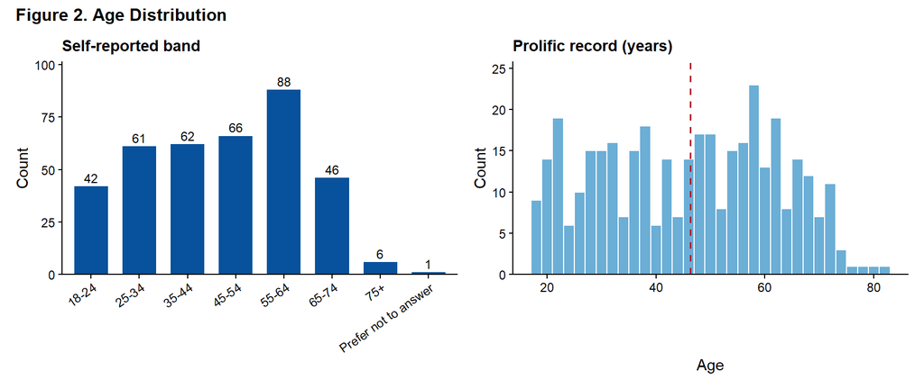

Table 6. Self-Reported Age Band by Prolific Age Band

| Self-reported | 18-24 | 25-34 | 35-44 | 45-54 | 55-64 | 65-74 | 75+ |
| --- | --- | --- | --- | --- | --- | --- | --- |
| 18-24 | 42 | 0 | 0 | 0 | 0 | 0 | 0 |
| 25-34 | 0 | 61 | 0 | 0 | 0 | 0 | 0 |
| 35-44 | 0 | 1 | 60 | 1 | 0 | 0 | 0 |
| 45-54 | 0 | 0 | 0 | 62 | 2 | 1 | 1 |
| 55-64 | 0 | 0 | 0 | 0 | 87 | 1 | 0 |
| 65-74 | 0 | 0 | 0 | 0 | 0 | 46 | 0 |
| 75+ | 0 | 0 | 0 | 0 | 1 | 0 | 5 |

363 of 371 (97.8%) agree. Excludes 1 who chose "prefer not to answer".

The sample skews middle-aged (mean 46.3, *SD* 16.1).

## 2.2 Education, Employment, and Income

Table 7. Education, Employment, and Household Income

| Measure | Response | N | % |
| --- | --- | --- | --- |
| Education | High school (diploma or GED) | 103 | 27.7 |
|  | Associate's degree | 39 | 10.5 |
|  | Bachelor's degree | 141 | 37.9 |
|  | Graduate or professional degree | 88 | 23.7 |
|  | Prefer not to answer | 1 | 0.3 |
| Employment | Employed full-time | 164 | 44.1 |
|  | Employed part-time | 55 | 14.8 |
|  | Self-employed | 55 | 14.8 |
|  | Unemployed | 16 | 4.3 |
|  | Retired | 49 | 13.2 |
|  | Full-time student | 10 | 2.7 |
|  | Homemaker / caregiver | 16 | 4.3 |
|  | Other | 3 | 0.8 |
|  | Prefer not to answer | 4 | 1.1 |
| Household income | Less than $25,000 | 31 | 8.3 |
|  | $25,000-$49,999 | 85 | 22.8 |
|  | $50,000-$74,999 | 71 | 19.1 |
|  | $75,000-$99,999 | 75 | 20.2 |
|  | $100,000-$149,999 | 61 | 16.4 |
|  | $150,000-$199,999 | 28 | 7.5 |
|  | $200,000-$249,999 | 8 | 2.2 |
|  | $250,000 or more | 5 | 1.3 |
|  | Prefer not to answer | 8 | 2.2 |

The modal participant holds a bachelor’s degree (37.9%) and works full-time (44.1%). Income is concentrated below $100,000 (70.4%), with only 11% at $150,000 or more. The sample is intended to be representative of the U.S. population.

## 2.3 Gender, Race, and Geography

Table 8. Gender and Racial / Ethnic Background

| Group | Category | N | % of sample |
| --- | --- | --- | --- |
| Gender | Woman | 184 | 49.5 |
|  | Man | 182 | 48.9 |
|  | Non-binary | 4 | 1.1 |
|  | Prefer not to answer | 2 | 0.5 |
| Race / ethnicity | White / Caucasian | 257 | 69.1 |
|  | Black American | 55 | 14.8 |
|  | Hispanic / Latino | 44 | 11.8 |
|  | East Asian | 19 | 5.1 |
|  | Native American | 12 | 3.2 |
|  | Black non-American | 5 | 1.3 |
|  | South Asian | 5 | 1.3 |
|  | Pacific Islander | 5 | 1.3 |
|  | None of the above | 5 | 1.3 |
|  | Southeast Asian | 3 | 0.8 |
|  | Middle Eastern | 3 | 0.8 |
|  | Prefer not to answer | 1 | 0.3 |

Race is multi-select, so those percentages sum above 100; 38 participant(s) selected more than one category.

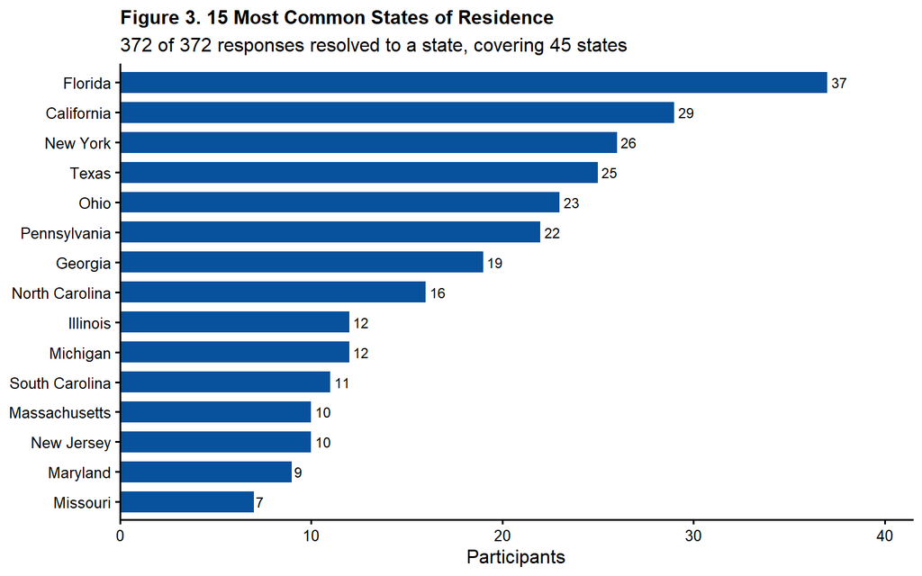

## 2.4 Household, Prior Planning, and Inheritance

Table 9. Household Composition, Prior Planning, and Inheritance

| Measure | Category | N | % |
| --- | --- | --- | --- |
| Has siblings | Yes | 328 | 88.2 |
|  | No | 42 | 11.3 |
|  | Prefer not to answer | 2 | 0.5 |
| Has children | Yes | 202 | 54.3 |
|  | No | 164 | 44.1 |
|  | Prefer not to answer | 6 | 1.6 |
| Prior EP action | Has a will | 103 | 27.7 |
|  | Has a trust | 42 | 11.3 |
|  | Named beneficiaries | 230 | 61.8 |
|  | Has a power of attorney | 87 | 23.4 |
|  | None of the above | 122 | 32.8 |
|  | Prefer not to answer | 3 | 0.8 |
| Received an inheritance | Yes | 110 | 29.6 |
|  | No | 256 | 68.8 |
|  | Prefer not to answer | 6 | 1.6 |
| Expects an inheritance | Yes | 130 | 34.9 |
|  | No | 154 | 41.4 |
|  | Not sure | 83 | 22.3 |
|  | Prefer not to answer | 5 | 1.3 |

Prior EP actions are multi-select. Among those with siblings, mean count = 2.35 (SD 1.52); among those with children, mean = 2.19 (SD 1.12).

Beneficiary designations are by far the most common prior EP-related action (61.8%), perhaps because the action is often associated with the opening of financial accounts and does not require a lawyer to officiate. Compared to that, only 27.7% of participants report having created a will and 11.3% having created a trust. 32.8% report no estate planning of any kind.

### 2.4.1 Inheritance and Estate Planning Literacy

Table 10. Literacy by Whether the Participant Has Received an Inheritance

| Measure | Received M (SD) | Not received M (SD) | Difference | t | p | Cohen's d |
| --- | --- | --- | --- | --- | --- | --- |
| Estate planning literacy (0-12) | 7.51 (2.71) | 6.10 (2.76) | +1.41 | 4.54 | < .001 | 0.51 |
| Financial literacy (0-12) | 9.56 (2.27) | 8.69 (2.47) | +0.87 | 3.28 | 0.001 | 0.36 |

Welch t-tests. Excludes 6 who chose "prefer not to answer".

Participants who have received an inheritance score higher on both scales, and the gap is larger for EPL (*d* = 0.51) than for FL (*d* = 0.36) — what you would expect if going through an estate teaches you about estates rather than raising general financial knowledge.

**WarningControlling for age**

Inheritors are on average 12.5 years older than non-inheritors (55.1 vs 42.6). Inheriting is also related to age. Adjusting for age shrinks the effect but does not remove it — inheritance is still worth +1.02 EPL points (*p* = 0.002) with age held constant.

# 3 Measures and Scoring

12 financial literacy items (from Fernandes et al., 2014) and 12 estate planning literacy items (self-generated). The EPL items split by content: `ep_1`–`ep_9` concern what a legal instrument does or who holds legal authority (intestacy, beneficiary designations, right of survivorship, powers of attorney, trust funding, guardianship); `ep_10`–`ep_12` concern the monetary consequences of an estate’s composition (debt satisfaction, illiquidity, net vs. gross value).

Table 11. Items and Hypothesised Factor Assignment

| Item | Block | Description |
| --- | --- | --- |
| fin_1 | FL | Interest 1% vs. inflation 2%: real purchasing power |
| fin_2 |  | T/F: Bonds are normally riskier than stocks |
| fin_3 |  | Highest return over 10-20 years |
| fin_4 |  | Asset with the highest fluctuation over time |
| fin_5 |  | Effect of spreading money across assets on risk |
| fin_6 |  | T/F: A $1,000 stock fund can be worth less on withdrawal |
| fin_7 |  | T/F: A stock mutual fund pools money to buy many stocks |
| fin_9 |  | T/F: 15-yr mortgage: higher payment, less total interest |
| fin_10 |  | $100 at 20% for 5 years (compounding) |
| fin_11 |  | Which statement is correct (stock/bond ownership) |
| fin_12 |  | Buying a bond of firm B: which statement is correct |
| fin_13 |  | $3,000 credit card debt, $30/month at 12% APR |
| ep_10 | EPL-Fin | Solely-owned credit card debt at death |
| ep_11 |  | Illiquid estate: house and business, little cash |
| ep_12 |  | Equal value: mortgaged house vs. cash account |
| ep_1 | EPL-Legal | Which statement about a will is correct |
| ep_2 |  | What generally happens when a person dies intestate |
| ep_3 |  | POD beneficiary vs. will (bank account) |
| ep_4 |  | Joint ownership with right of survivorship vs. will |
| ep_5 |  | Incapacity with a will but no financial POA |
| ep_6 |  | House titled in a revocable trust vs. will |
| ep_7 |  | Retirement account beneficiary vs. will |
| ep_8 |  | Trust-funded house vs. car left in own name |
| ep_9 |  | Naming a guardian for a minor child in a will |

**Scoring.** Every item is scored as a binary: either correct or incorrect. Because all indicators are binary, items are declared `ordered` and estimated with **WLSMV** (diagonally weighted least squares, mean- and variance-adjusted).

# 4 Item-Level Results

Table 12. Item Statistics (Analysis Sample, N = 372)

| Item | Block | Pass rate (%) | Item-rest r | Std. loading |
| --- | --- | --- | --- | --- |
| fin_1 | FL | 83.6 | 0.460 | 0.676 |
| fin_2 |  | 86.3 | 0.404 | 0.690 |
| fin_3 |  | 61.6 | 0.351 | 0.555 |
| fin_4 |  | 91.4 | 0.315 | 0.656 |
| fin_5 |  | 82.3 | 0.461 | 0.738 |
| fin_6 |  | 79.8 | 0.344 | 0.503 |
| fin_7 |  | 83.9 | 0.355 | 0.589 |
| fin_9 |  | 91.1 | 0.249 | 0.502 |
| fin_10 |  | 75.8 | 0.241 | 0.380 |
| fin_11 |  | 69.4 | 0.402 | 0.632 |
| fin_12 |  | 57.0 | 0.496 | 0.765 |
| fin_13 |  | 31.7 | 0.345 | 0.617 |
| ep_10 | EPL-Fin | 69.4 | 0.319 | 0.612 |
| ep_11 |  | 67.7 | 0.438 | 0.793 |
| ep_12 |  | 69.4 | 0.471 | 0.786 |
| ep_1 | EPL-Legal | 79.3 | 0.305 | 0.575 |
| ep_2 |  | 55.4 | 0.440 | 0.750 |
| ep_3 |  | 60.5 | 0.292 | 0.457 |
| ep_4 |  | 41.1 | 0.283 | 0.544 |
| ep_5 |  | 28.0 | 0.341 | 0.521 |
| ep_6 |  | 33.1 | 0.322 | 0.516 |
| ep_7 |  | 45.7 | 0.404 | 0.541 |
| ep_8 |  | 52.7 | 0.388 | 0.568 |
| ep_9 |  | 45.4 | 0.261 | 0.431 |

Item-rest r is the point-biserial correlation between the item (scored 0/1) and the summed score on the remaining items in its own block, with the item itself excluded. Standardized loadings come from the three-factor model in Section 5.

The items provide fairly good coverage across levels of difficulty, as reflected in the proportion of participants who answered each item correctly.

EPL items elicit substantially more “I don’t know” responses than FL items (11.6% vs 7.4% on average), consistent with participants having less familiarity or prior exposure to estate-planning knowledge.

## 4.1 Item-Rest Correlation

The **pass rate** describes how *difficult* an item is. The **item-rest correlation** describes how well the item *discriminates* — whether the people who do well on the rest of the scale are also the people who get this item right.

It is computed by scoring the item 0/1, summing each participant’s score on **all the other items in that item’s own block**, and correlating the two.

**How to interpret the values:**

| Item-rest *r* | Reading |
| --- | --- |
| **≥ .30** | Conventionally adequate. High scorers reliably get it right. |
| **.20–.30** | Weak but usable, especially for a very easy or very hard item. |
| **0–.20** | Contributes little. The item is close to unrelated to the rest of the scale. |
| **≤ 0** | Red flag. People who do well elsewhere tend to get this item *wrong* — usually a miskeyed answer, ambiguous wording, or an item measuring something else entirely. |

**WarningVery easy and very hard items are mechanically penalized**

If 95% of people answer an item correctly there is almost no variance left for it to correlate with anything, so a modest item-rest *r* on an extreme item is not by itself evidence of a bad item.

In this instrument every item-rest correlation is positive, ranging from 0.24 to 0.50. **No item behaves in reverse**, which is the failure mode that matters most.

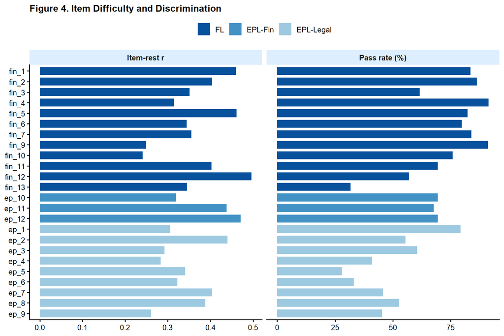

## 4.2 Reliability

I report Cronbach’s alpha as an additional measure of the extent to which the items covary and exhibit internal consistency.

Table 13. Internal Consistency

| Scale | k items | Alpha (KR-20) | Mean inter-item r |
| --- | --- | --- | --- |
| Financial literacy | 12 | 0.733 | 0.189 |
| Estate planning literacy | 12 | 0.729 | 0.184 |
| EPL: financial consequences | 3 | 0.599 | 0.332 |
| EPL: legal/administrative | 9 | 0.661 | 0.178 |
| All 24 items | 24 | 0.816 | 0.157 |

## 4.3 The Correlation Structure Behind the Models

I report tetrachoric correlations to assess whether the items are meaningfully related while remaining sufficiently distinct from one another (i.e., no correlations approaching 0.90).

**What to look for.** If the three sets of items reflect three distinct factors, then the diagonal blocks of the correlation matrix below (which show correlations among items within the same factor) should appear darker than the off-diagonal blocks (which show correlations among items across factors).

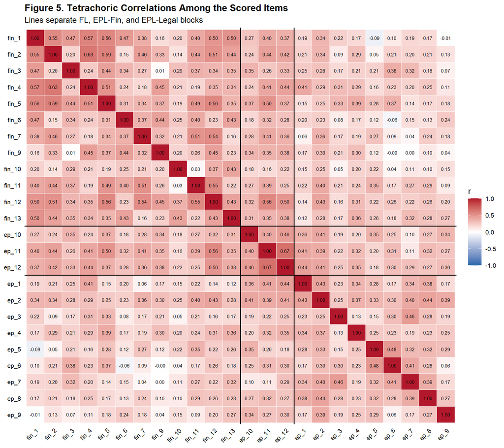

Table 14. Mean Tetrachoric Correlation Within and Between Blocks

|  | FL | EPL-Fin | EPL-Legal |
| --- | --- | --- | --- |
| FL | 0.355 | 0.339 | 0.200 |
| EPL-Fin | 0.339 | 0.511 | 0.290 |
| EPL-Legal | 0.200 | 0.290 | 0.291 |

Diagonal cells are the mean correlation among items within a block; off-diagonal cells are the mean correlation between items of different blocks.

**Reading the pattern.** Items do cohere more with their own block than with others — mean within-block *r* = 0.39 versus between-block *r* = 0.28. That gap is what Question 1 detects as distinguishable factors. But notice how modest it is, and notice two specific cells:

- **FL with EPL-Fin (0.34) is almost as high as FL with itself (0.35).** The EPL-Fin items are nearly as related to the financial literacy items as the financial literacy items are to each other. This is the same finding that recurs throughout the document, visible here in the raw correlations before any model is fitted.
- **EPL-Legal with itself (0.29) is barely above EPL-Legal with EPL-Fin (0.29).**

The other thing to notice is what the whole matrix looks like: **almost every cell is positive and moderate**, averaging at 0.28. Most items are positively related to nearly every other item, even when compared to items that belong to a different factor.

This figure foreshadows both answers to come: there exists a multi-factor structure (Question 1 — the factors are distinguishable), but there seems to be a general factor too (Question 2 — the strong correlations between the factors reflects a broader ability shared across all items).

# 5 Question 1: Do the items load onto a single “general literacy factor or distinct factors?

The first question is whether financial literacy and estate planning literacy are separate things at all, and whether EPL itself splits in two factors. We answer this question by testing the fit of three latent models.

## 5.1 The Three Models

- **One-factor**: all 24 items load on a single general knowledge factor.
- **Two-factor**: FL and EPL, freely correlated.
- **Three-factor**: FL, EPL-Fin, and EPL-Legal, all freely correlated.

Each is nested in the next, so the added factors can be tested with scaled chi-square difference tests.

## 5.2 Fit and Model Comparison

Table 15. Model Fit (N = 372)

| Model | chi2 | df | p | CFI | TLI | RMSEA | RMSEA 90% CI | WRMR |
| --- | --- | --- | --- | --- | --- | --- | --- | --- |
| One-factor | 409.6 | 252 | < .001 | 0.915 | 0.907 | 0.041 | [0.034, 0.048] | 1.113 |
| Two-factor | 343.9 | 251 | < .001 | 0.950 | 0.945 | 0.032 | [0.023, 0.040] | 0.996 |
| Three-factor | 311.8 | 249 | 0.004 | 0.966 | 0.962 | 0.026 | [0.015, 0.035] | 0.932 |

All indices are the scaled/robust versions appropriate to WLSMV. Conventional thresholds: CFI/TLI >= .95, RMSEA <= .06, WRMR <= 1.0.

Table 16. Scaled Chi-Square Difference Tests

| Comparison | Scaled chi2 diff | df diff | p | Verdict |
| --- | --- | --- | --- | --- |
| Two-factor vs. one-factor | 33.56 | 1 | < .001 | More factors preferred |
| Three-factor vs. two-factor | 20.67 | 2 | < .001 | More factors preferred |

Satorra (2000) scaled difference test for WLSMV-estimated models.

Each added factor improves fit significantly, and only the three-factor model clears every conventional threshold at once.

## 5.3 The Fitted Three-Factor Model

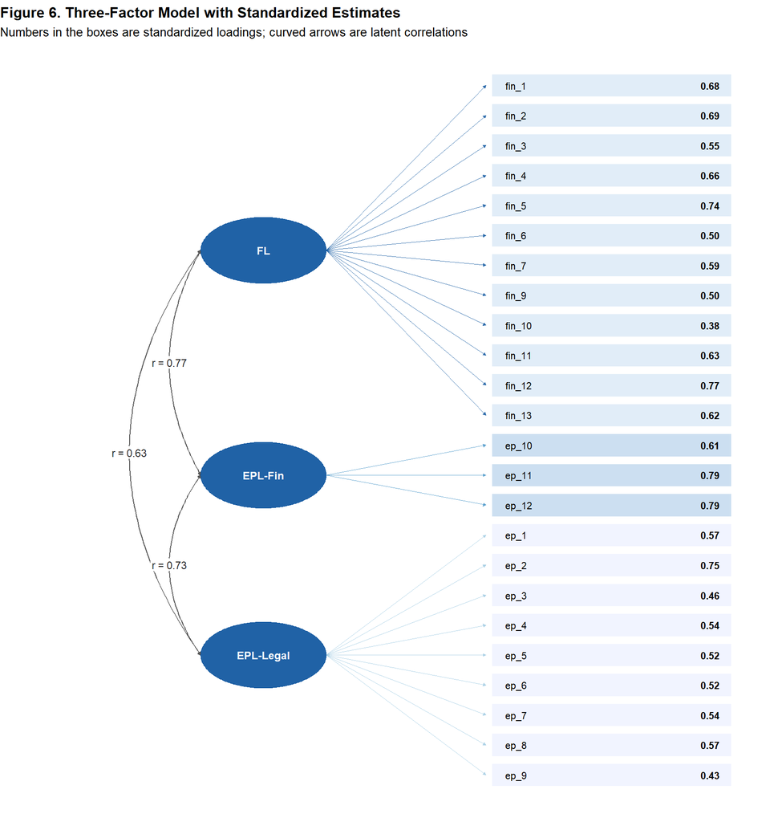

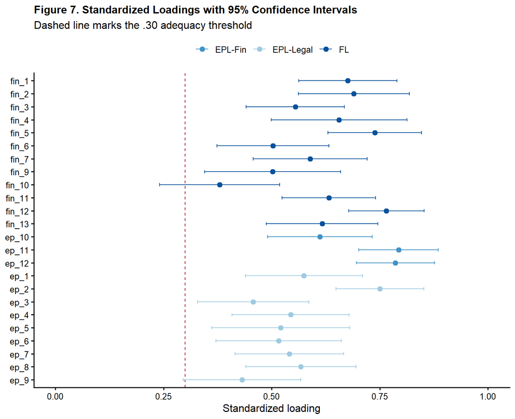

Table 17. Latent Factor Correlations

| Pair | r | SE | 95% CI | p |
| --- | --- | --- | --- | --- |
| FL - EPL_FIN | 0.771 | 0.055 | [0.664, 0.879] | < .001 |
| FL - EPL_LEG | 0.631 | 0.056 | [0.520, 0.741] | < .001 |
| EPL_FIN - EPL_LEG | 0.727 | 0.060 | [0.608, 0.845] | < .001 |

All 24 loadings are strong and significant (range 0.38–0.79). The factors correlate 0.63–0.77 — reliably below 1.0, which is what “distinguishable” means, but high enough that they share 40–60% of their variance.

## 5.4 Robustness: Testing the 3-factor model against every 2-factor definition

The comparison above tests the three-factor model against a *pre-defined* two-factor model that separates FL items from EPL items. However, the three factors can be merged into two factors in three different ways, and a skeptic could reasonably ask whether these results depend on which 2-factor definition was chosen. This section was created to test the robustness of these results against alternative 2-factor definitions.

Table 18. Fit of All Five Single-Level Groupings

| Model | chi2 | df | CFI | TLI | RMSEA | WRMR |
| --- | --- | --- | --- | --- | --- | --- |
| 1F: one general factor | 409.6 | 252 | 0.915 | 0.907 | 0.041 | 1.113 |
| 2F-A: {FL} {EPL-Fin + EPL-Legal} | 343.9 | 251 | 0.950 | 0.945 | 0.032 | 0.996 |
| 2F-B: {FL + EPL-Fin} {EPL-Legal} | 338.8 | 251 | 0.953 | 0.948 | 0.031 | 0.986 |
| 2F-C: {FL + EPL-Legal} {EPL-Fin} | 397.8 | 251 | 0.921 | 0.913 | 0.040 | 1.093 |
| 3F: {FL} {EPL-Fin} {EPL-Legal} | 311.8 | 249 | 0.966 | 0.962 | 0.026 | 0.932 |

Table 19. Each Simpler Grouping Tested Against the Three-Factor Model

| Restricted model | Scaled chi2 diff | df diff | p |
| --- | --- | --- | --- |
| 1F | 59.21 | 3 | < .001 |
| 2F-A | 20.67 | 2 | < .001 |
| 2F-B | 20.39 | 2 | < .001 |
| 2F-C | 62.93 | 2 | < .001 |

A significant result means the simpler model fits significantly worse, i.e. the three-factor model is preferred.

Every 2-factor model, regardless of how the factors are grouped, fits significantly worse, and none of the comparisons is close to the .05 boundary. This shows that our results - that a 3-factor model fits substantially better than a 2-factor model - are not an artifact of how the 2-factor model happened to be defined. The 3-factor model also beats the two *alternative* 2-factor models.

If forced to pick a 2-factor model, 2F-B actually fits best. The 2-factor models all share the same degrees of freedom, so their chi-squares are directly comparable: 2F-B ($\chi^2$ = 338.8) edges out 2F-A ($\chi^2$ = 343.9), while 2F-C ($\chi^2$ = 397.8) is far worse. So, the EPL-Fin factor actually aligns marginally better with FL than with EPL-Legal — but the gap is small, and the decisive fact is that 2F-C fails badly: EPL-Fin is not a free-floating block, it sits *between* the other two.

# 6 Question 2: Do each of the factors measure something meaningful on their own?

Question 1 established that the three factors are *distinguishable*. A model that distinguishes FL, EPL-Fin, and EPL-Legal fits the data better than models that collapse these domains together. However, the three factors are also strongly correlated (0.63–0.77), suggesting that much of what they measure is shared.

## 6.1 What this Question Asks

Suppose two FL items are correlated. That correlation could arise from at least two sources:

1. **A general source of knowledge or ability shared across the entire instrument.** Someone who tends to perform well on FL items may also tend to perform well on EPL-Fin and EPL-Legal items.
2. **Something specific to FL.** Even among people with the same level of general knowledge, some may be especially knowledgeable about the content covered by the FL items.

The correlated three-factor model does not separate these two sources. The FL factor represents everything the FL items have in common, including both the variance they share with the other domains and any variance that is unique to FL. The same is true for the EPL-Fin and EPL-Legal factors. Their strong correlations therefore tell us that the three domains share a substantial common component, but they do not tell us how much each domain measures beyond that common component.

The bifactor model separates these sources. It estimates a general factor that loads on all 24 items and, at the same time, a specific factor for each block. The specific FL factor therefore represents what the FL items still have in common after accounting for the general factor; likewise for EPL-Fin and EPL-Legal.

The key question is:

> **After accounting for the general factor shared across the instrument, do the items within each block still covary with one another in a systematic way?**

If they do, the block contains reliable domain-specific information beyond the general factor. If little or no shared variance remains, then the factor is distinguishable in the overall covariance structure but contributes little evidence of a separate individual-difference dimension once the general factor is taken into account.

**TipAn analogy: restaurant ratings**

Imagine restaurants are evaluated using several questions about food, several about service, and several about atmosphere. Ratings across these domains will often correlate because restaurants that are good in one respect also tend to be good in others.

**Question 1** asks whether food, service, and atmosphere are distinguishable dimensions. Do the food questions behave more similarly to one another than they do to the service or atmosphere questions? If so, treating the three domains separately describes the data better than treating every rating as a measure of one undifferentiated notion of restaurant quality.

**Question 2** asks a different question. Once you account for a restaurant’s overall quality, ddo the food questions still move together in a way that is specifically about food? For example, among two restaurants with the same overall quality, can one be reliably better at food while the other is better at service?

If yes, a food sub-rating contains information beyond the overall rating. If no, the food questions mainly reflect overall restaurant quality, with little reliable food-specific information left over. In that case, differences between a restaurant’s overall score and its food subscore may largely reflect measurement noise rather than a stable, food-specific strength or weakness.

For one of our three factors, the answer turns out to be the second one.

One way to represent the commonality among the three factors is with a second-order model, in which a general literacy factor sits above FL, EPL-Fin, and EPL-Legal. The general factor accounts for what the three first-order factors share, while each first-order factor also retains residual variance of its own.

With only three first-order factors, however, this model has exactly the same fit as the correlated three-factor model (see Table 20 below). The second-order portion is just-identified: it can reproduce the three correlations among FL, EPL-Fin, and EPL-Legal exactly. Thus, although we can estimate higher-order loadings, the data cannot tell us whether this higher-order representation provides a better explanation of the correlations than simply allowing the three factors to correlate.

To ask the more specific question above—whether each domain retains coherent variance after accounting for what all of the items share—we instead fit a bifactor model. In this model, the general factor and the three domain-specific factors are estimated simultaneously at the item level. Each item loads directly on the general factor as well as on its own specific factor, allowing us to separate variance shared across the entire instrument from variance unique to each domain.

Table 20. Second-Order vs. Correlated Three-Factor

| Model | chi2 | df | CFI | TLI | RMSEA | WRMR |
| --- | --- | --- | --- | --- | --- | --- |
| Correlated three-factor | 311.8 | 249 | 0.966 | 0.962 | 0.026 | 0.932 |
| Second-order | 311.8 | 249 | 0.966 | 0.962 | 0.026 | 0.932 |

Identical fit and degrees of freedom: the second-order level is just-identified with three first-order factors, so this is a reparameterisation rather than a rival model.

## 6.2 Testing the Bifactor Model

**Caution**

I am still working through some of the technical details in this section and the following sections, so the interpretation below should be treated as provisional for now.

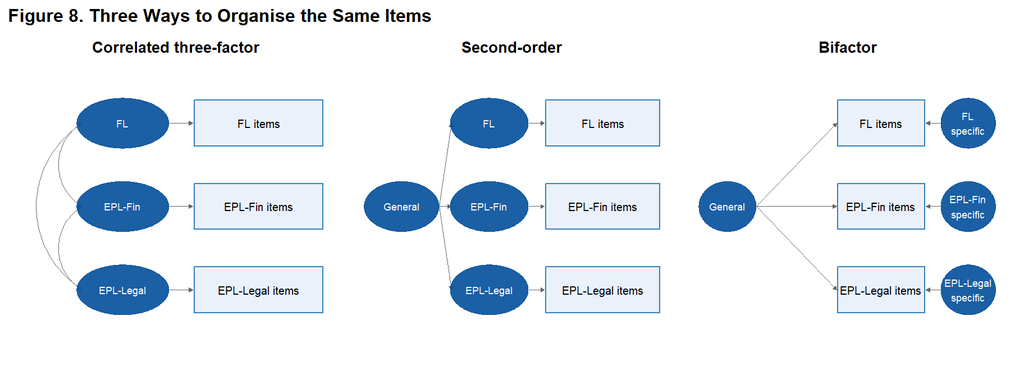

In a bifactor model, the general factor loads on **every item directly**, and each specific factor is fitted to its own items *at the same time*. The general and specific factors are forced to be uncorrelated, so they cannot claim the same variance twice. Each item’s variance therefore splits cleanly into three parts: what it shares with all 24 items, what it shares only with its own block, and noise.

**NoteInterpreting the diagram**

The general factor is the part every item has in common. The specific factors are what is left inside each block *after* that part has been taken out — the food-specific signal in the restaurant analogy above. Because the two are forced to be uncorrelated, a specific factor can only exist if its block’s items still hang together once the general factor has taken its share.

## 6.3 Fitting the Model

Estimating the full bifactor — general factor plus all three specific factors — produces a degenerate solution rather than an answer.

Table 21. The EPL-Fin Specific Factor Collapses

| Parameter | Estimate |
| --- | --- |
| EPL-Fin specific =~ ep_10 | 0.000 |
| EPL-Fin specific =~ ep_11 | 0.001 |
| EPL-Fin specific =~ ep_12 | 102.349 |
| Residual variance of ep_12 | -10475 |

lavaan also reports that the information matrix cannot be inverted, so this model has no standard errors and no robust fit statistics.

Two of the three EPL-Fin specific loadings sit at zero, the third runs away, and `ep_12` absorbs an impossible negative residual variance. **This is the answer to Question 2 for that block, not a failure to obtain one.** A specific factor can only be estimated if there is leftover covariance to estimate it from, and here there is none: once the general factor has taken its share, the three financial-consequence items no longer hang together at all. They correlate with each other only to the extent that they correlate with everything else on the instrument.

In the restaurant analogy, this is the case where the food ratings carry no food-specific signal — they are just the overall impression, recorded a third time.

Two ways of making the model estimable both confirm it:

Table 22. Bifactor Variants

| Model | chi2 | df | CFI | TLI | RMSEA | WRMR |
| --- | --- | --- | --- | --- | --- | --- |
| Correlated three-factor (Question 1) | 311.8 | 249 | 0.966 | 0.962 | 0.026 | 0.932 |
| Bifactor, all three specific factors | -- | 228 | -- | -- | -- | 0.859 |
| Bifactor, EPL-Fin loadings constrained equal | 285.4 | 230 | 0.970 | 0.964 | 0.025 | 0.864 |
| Bifactor, EPL-Fin specific factor removed | 286.0 | 231 | 0.970 | 0.964 | 0.025 | 0.866 |

Constraining the three EPL-Fin specific loadings to a common value turns the question into a single-parameter test: that loading is 0.229 (SE 0.121, p = 0.058, 95% CI [-0.008, 0.466]). Deleting the factor entirely costs almost nothing in fit. Bifactor models are not nested in the correlated three-factor model, so fit is compared descriptively.

The remaining analysis uses the reduced bifactor — general factor, FL specific factor, EPL-Legal specific factor, with the EPL-Fin items loading on the general factor only. It estimates cleanly with all residual variances positive.

## 6.4 How Much Is General, How Much Is Specific?

Table 23. How the Variance Divides

| Index | Value |
| --- | --- |
| ECV — share of common variance held by the general factor | 0.661 |
| omega-H — share of total-score variance held by the general factor | 0.760 |
| omega — total reliability of the full scale | 0.919 |
| omega-H / omega — share of *reliable* variance that is general | 0.827 |
| omega-HS, FL specific factor | 0.323 |
| omega-HS, EPL-Legal specific factor | 0.314 |
| omega-HS, EPL-Fin specific factor | not estimable (factor collapsed) |
| Items whose common variance is mostly specific (I-ECV < .50) | 7 of 24 |

omega-HS is the share of a subscale score's variance attributable to its own specific factor once the general factor is removed. Values below about .50 mean a subscale score is mostly not measuring anything of its own.

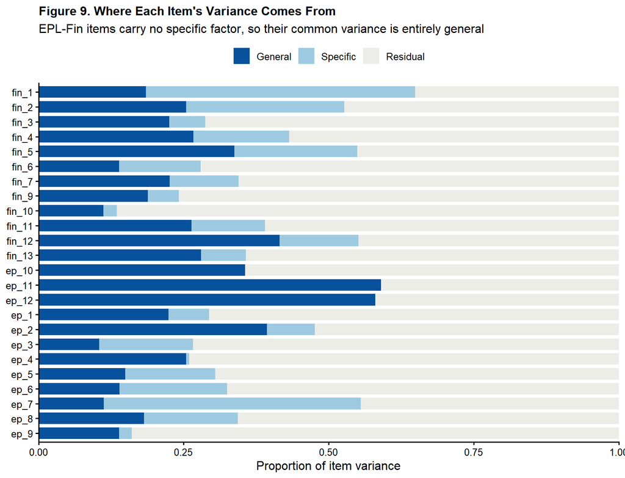

**The answer to Question 2, block by block:**

- **FL**: some coherent specific variance remains, but not much — ωHS = 0.32. An FL subscore is roughly 32% “financial literacy specifically” and the rest general knowledge.
- **EPL-Legal**: similar, ωHS = 0.31. This is the block with the most distinctive content, and even it does not clear the ~.50 usually required to interpret a subscore on its own.
- **EPL-Fin**: **none.** The specific factor cannot be estimated because there is no leftover covariance to estimate it from. These three items are, measurement-wise, three more indicators of general knowledge that happen to be phrased in estate language.

Overall, 66% of the common variance across the 24 items belongs to the general factor, and 83% of the *reliable* variance in a total score is general-factor variance.

It is not pure unidimensionality, though. 7 of 24 items have more of their common variance in the specific factor than in the general one — `ep_7` (retirement account beneficiary vs. will) most of all, at 80% specific. Real domain structure exists. It is outweighed, not absent.

**WarningTwo caveats on the bifactor**

**It flatters itself.** Bifactor models fit better than their competitors close to mechanically, because extra orthogonal factors absorb residual covariance whether or not a general factor is substantively real. Its good fit is not evidence for a general factor; the *variance shares* are the informative output, not the fit indices.

**The reduced model is data-driven.** Deleting the EPL-Fin specific factor after seeing the full model fail is a decision made in light of the data. It is well justified here — two independent repairs agree, and the constrained loading is 0.23 with a confidence interval containing zero — but the indices above inherit that choice, so treat them as approximate. Bifactor indices from binary items under WLSMV are also less well studied than their continuous-data counterparts.

# 7 Reconciling the Two Answers

The two questions give answers that sound contradictory:

- **Question 1**: the three-factor model fits significantly better than one factor. The blocks are distinguishable.
- **Question 2**: about two-thirds of the common variance belongs to a single general factor, and one block has no specific variance at all.

These results are not contradictory. They speak to different questions.

## 7.1 What Each Test Actually Asks

Table 24. The Two Questions Side by Side

|  | Question 1 (model comparison) | Question 2 (variance partition) |
| --- | --- | --- |
| The question | Are these factors the same thing? | How much variance do these factors share? |
| The quantity | Is the correlation between factors reliably below 1.0? | What proportion of common variance is general vs. specific? |
| The answer here | No, they are not the same thing (p < .001) | Most of it is shared (ECV = 0.66) |
| What it licenses | Modelling them separately; treating EPL as its own construct | Reporting a total score; treating the scale as essentially one dimension for scoring |
| What it does NOT license | Claiming they are independent, or that subscores are meaningful | Claiming the blocks are interchangeable, or that a one-factor model is correct |

The crucial point is that **a difference can be statistically reliable and substantively small at the same time.** The chi-square difference test asks whether the correlation between two factors is *distinguishable from a perfect 1.0*. It does not ask whether the correlation is *low*. With *N* = 372, a correlation of 0.77 is comfortably distinguishable from 1.0 — and 0.77 still means the two factors share 60% of their variance.

Your own fit indices show the same thing from the other direction. The one-factor model — the model that says all 24 items measure one thing — already achieves CFI = 0.915. That is not a disaster; it is a mediocre-but-recognisable fit. The three-factor model improves it to 0.966. The improvement is real and statistically significant, and it is also an improvement on a model that was already capturing most of the structure. **“Significantly better than one factor” and “one factor gets you most of the way” are both true statements about the same numbers.**

## 7.2 Analogies to Aid Interpretation of Results

**TipThree analogies**

**The decathlon.** Sprinting, hurdling, and the long jump are genuinely different events. A coach can tell them apart, athletes specialise, and nobody would claim they are the same skill — that is Question 1. But most of what determines how well someone does across all three is general athleticism: strength, speed, coordination. That is Question 2. Both are true. The practical consequence is exactly what we recommend here: to rank decathletes overall, use the total score; to decide who should run the hurdles specifically, you would need the event-specific part — and in our data that part is measured too unreliably to use.

**Siblings.** Three siblings are unmistakably different people; you would never confuse them, and a statistical test would separate them instantly. Yet most of what makes each of them look the way they do is shared family resemblance. “Reliably distinguishable” and “mostly the same underlying thing” are not in tension — they are the normal state of affairs for things that come from a common source.

**Zoom level on a map.** Zoomed in, you see three distinct neighbourhoods with their own boundaries and character. Zoomed out, it is obviously one city. Neither view is wrong; they answer different questions. Question 1 is the zoomed-in view, Question 2 the zoomed-out one, and a good write-up reports both.

## 7.3 What This Means in Practice

- **Keep the three-factor model as the measurement model.** It fits best, and a one-factor model is statistically rejected. If you are estimating relationships between EPL and other variables, model it as its own factor.
- **Report a total score, not subscores.** The general factor carries 83% of the reliable variance; the FL and EPL-Legal subscores carry 0.32 and 0.31 of their own. An EPL-Fin subscore should not be reported at all.
- **Do not describe the constructs as independent.** They share 40–60% of their variance. “Distinguishable” is the correct word; “distinct” or “separate” oversells it.
- **Let the validity evidence carry the argument.** The strongest case that EPL is worth measuring is not the factor structure — it is Section 8, where estate planning engagement is associated with EPL net of financial literacy while the reverse partial correlation is zero. High overlap in variance is compatible with the non-overlapping part being the part that matters.

# 8 Is Estate Planning Engagement Related to EPL Above and Beyond FL?

This section relates the scales to a behavioral measure available in the data, the **number of estate planning actions a participant has already completed** (will, trust, beneficiary designations, power of attorney; 0–4). We refer to this variable below as *EP engagement*.

The question addressed is:

> Is EP engagement related to estate planning literacy **over and above** what it shares with financial literacy?

## 8.1 Zero-Order Associations

First, we examine the correlations between all three factors - split and then, EPL combined - and EP engagement.

Table 25. Correlation of Each Scale with EP Engagement

| Scale | r | 95% CI | p |
| --- | --- | --- | --- |
| Estate planning literacy (all 12) | 0.265 | [0.168, 0.357] | < .001 |
| EPL: financial consequences | 0.194 | [0.094, 0.290] | < .001 |
| EPL: legal/administrative | 0.249 | [0.151, 0.342] | < .001 |
| Financial literacy | 0.161 | [0.061, 0.259] | 0.002 |

EP engagement is the count of completed estate planning actions (0-4). The EPL-FL difference in the first and last rows is tested below; the two EPL subscales are shown indented for reference. FL and EPL themselves correlate at 0.52.

All factors are related to EP engagement, and estate planning literacy more so than financial literacy: *r* = 0.265 versus 0.161 for financial literacy. Because the FL and EPL factors are themselves correlated at 0.52, the difference between those two correlations should be tested using a method that accounts for **dependent** correlations.

Table 26. Is EPL More Strongly Related to Engagement than FL Is?

| Comparison | r (EPL) | r (FL) | Difference | t | p |
| --- | --- | --- | --- | --- | --- |
| EPL vs. FL, correlation with EP engagement | 0.265 | 0.161 | +0.104 | 2.12 | 0.035 |

Steiger's test for two dependent correlations sharing one variable (EP engagement).

The difference in correlation strength is 0.104, and it is statistically significant (*p* = 0.035). EPL is more strongly associated with prior EP engagement than FL is.

## 8.2 Above and Beyond: Partial Correlations

The zero-order correlations do not answer the question on their own, because FL and EPL overlap heavily. A **partial correlation** removes that overlap: the correlation between EP engagement and EPL, with financial literacy held constant, is the association that survives after everything the two scales share has been taken out of both.

Table 27. Association with EP Engagement, Net of the Other Scale

| Association | Held constant | Partial r | Partial p | Semipartial r | Unique share of engagement variance |
| --- | --- | --- | --- | --- | --- |
| EP engagement - EPL | Financial literacy | 0.215 | < .001 | 0.212 | 4.5% |
| EP engagement - FL | Estate planning literacy | 0.028 | 0.591 | 0.027 | 0.1% |

Partial r removes the other scale from both variables and is symmetric — it makes no claim about which variable is the cause. Semipartial r removes the other scale from the literacy measure only; its square is the share of engagement variance uniquely associated with that scale.

**ImportantEPL may be worth measuring separately**

Holding financial literacy constant, EP engagement remains associated with estate planning literacy at *r* = 0.215 (*p* < .001).

Holding estate planning literacy constant, the association with financial literacy is only *r* = 0.028 (*p* = 0.591), which is not significantly different from zero.

In other words, **the entire association between financial literacy and estate planning engagement is accounted for by what financial literacy shares with EPL.** Once that shared part is removed, nothing is left. The reverse is not true: EPL retains a clear association after FL is removed, uniquely accounting for 4.5% of the variance in engagement against 0.1% for FL.

This matters because Sections 5 and 6 found the two factors share most of their variance — which on its own looks like a discriminant validity problem. The part they *do not* share turns out to be the part that may be related to behavior.

**The claim here is comparative, not a claim about magnitude.** In absolute terms 4.5% is a small share of variance, and Section 8.3 takes that seriously rather than glossing it.

Table 28. The Two EPL Subscales, Net of Financial Literacy

| Association | Held constant | Partial r | Partial p | Semipartial r |
| --- | --- | --- | --- | --- |
| EP engagement - EPL-Legal | Financial literacy | 0.201 | < .001 | 0.199 |
| EP engagement - EPL-Fin | Financial literacy | 0.132 | 0.011 | 0.130 |

Both EPL subscales retain an association with engagement after financial literacy is removed, the legal/administrative block more strongly.

## 8.3 How Big Is This, Really?

Uniquely accounting for 4.5% of the variance in engagement is, in absolute terms, **small**. It is worth being direct about that rather than letting a percentage do rhetorical work.

Table 29. Putting the Variance Shares in Context

| Quantity | Value |
| --- | --- |
| Variance in engagement explained by age alone | 7.8% |
| Variance explained by FL and EPL together | 7.1% |
| Variance explained by age, FL, and EPL together | 11.9% |
| Unique share attributable to EPL | 4.5% |
| Unique share attributable to FL | 0.1% |

Two things nonetheless keep the result meaningful.

**1. The same association looks larger expressed as a group difference.** Squaring a correlation makes it look small; it is the same number either way.

Table 30. EPL Score by Whether Any Estate Planning Has Been Done

| Comparison | N | Mean EPL score (of 12) |
| --- | --- | --- |
| No EP actions completed | 125 | 5.25 |
| One or more completed | 247 | 7.10 |
| Difference |  | +1.85 |

Welch t = 6.24, p < .001. Cohen's d = 0.65, a medium-to-large difference. The equivalent gap on the FL scale is 0.37 SD.

Participants who have done nothing score 5.25 on the 12-item EPL scale; those who have done anything at all score 7.10. That is 0.65 standard deviations — a medium-to-large difference by conventional benchmarks — and it is the *same* fact as the modest *r*. “Explains 4.5% of variance” and “a two-thirds-of-a-standard-deviation gap” describe one relationship.

**2. Small is the norm in this literature — and FL’s result here is a textbook example of it.** The financial literacy items used here come from Fernandes, Lynch and Netemeyer’s (2014) meta-analysis, whose headline finding was that interventions to improve financial literacy account for roughly **0.1% of the variance** in the downstream financial behaviors studied (I need to fact-check this claim, but if it’s true then that is interesting). The unique share attributable to FL in these data is 0.1% — essentially that same number. Against that benchmark, EPL’s 4.5% is not a small result; it is roughly 62 times larger.

**NoteSection Summary**

The value of this section is **discriminant**: it shows the EPL items capture something behaviorally relevant that the FL items do not. It is not an effect-size claim, and it should not be written up as one.

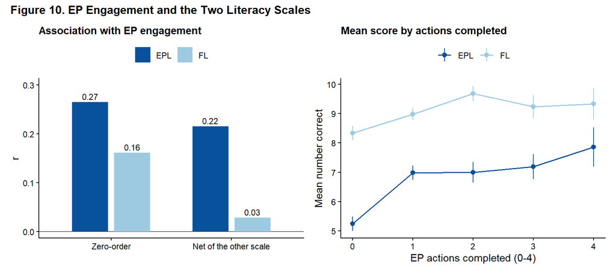

**NoteWhat this does and does not establish**

It establishes that EP engagement is related to estate planning literacy in a way that financial literacy cannot account for, and that the reverse does not hold.

It does not establish direction. Someone who has drafted a will may score higher on EPL **because** they went through the process — a professional explained beneficiary designations to them — rather than having acted because they already knew. Both readings are consistent with these numbers, as is a third in which family circumstances drive both. Describe the finding as an **association net of financial literacy**, not as evidence that knowledge causes action.

# 9 Exploratory Analyses

In the survey, we included several additional measures that were not part of the measurement question. The measures are analyzed below for exploratory purposes.

## 9.1 Prior Exposure to the Financial Literacy Items

After answering the knowledge items, participants rated how certain they were that they had **seen each FL item prior to taking our survey**. The item `exp_8` is excluded to match the exclusion of `fin_8`, leaving 12 ratings that pair one-to-one with the 12 FL items.

If participants have seen these items before, then part of what FL measures is prior exposure rather than knowledge.

Table 31. Self-Reported Prior Exposure and Knowledge Scores

| Association | r | 95% CI | p |
| --- | --- | --- | --- |
| Mean prior-exposure rating - FL score | 0.202 | [0.102, 0.297] | < .001 |
| Mean prior-exposure rating - EPL score | 0.098 | [-0.004, 0.198] | 0.059 |

Exposure is the mean of 12 items rated 1-5 (alpha = 0.95); mean 2.80 (SD 1.24).

Table 32. Item by Item: Reported Exposure and Answering That Item Correctly

| Item | r | p |
| --- | --- | --- |
| fin_1 | 0.101 | 0.052 |
| fin_2 | 0.135 | 0.009 |
| fin_3 | 0.037 | 0.478 |
| fin_4 | 0.022 | 0.669 |
| fin_5 | 0.113 | 0.030 |
| fin_6 | 0.062 | 0.235 |
| fin_7 | 0.137 | 0.008 |
| fin_9 | 0.151 | 0.004 |
| fin_10 | 0.107 | 0.038 |
| fin_11 | 0.147 | 0.004 |
| fin_12 | 0.038 | 0.465 |
| fin_13 | 0.175 | < .001 |

Mean within-item correlation = 0.102; significant at p < .05 for 7 of 12 items.

Participants who report having seen these items before **do score higher** on financial literacy (*r* = 0.202, *p* < .001), and the effect is visible item by item (see Table 32 above).

The exposure measure also behaves sensibly relative to the EPL items: prior exposure to the FL items correlate roughly twice as strongly with **FL** than with **EPL** (*r* = 0.098). This is what we would expect if prior exposure to the items improves one’s performance on them.

Thus, some of the FL score reflects item familiarity rather than financial knowledge, which is a known hazard of reusing a widely circulated battery on an online panel. It is a modest effect and it does not threaten the measurement conclusions — but it is a reason to prefer the EPL items when a clean knowledge measure is wanted, and a reason to consider refreshing the FL battery in future waves.

### 9.1.1 Does Prior Exposure Affect the Factor Structure?

If familiarity is inflating FL scores but not EPL scores, this could explain why the three-factor model fit the data best. Here, for robustness, I refit the models on participants who report little or no prior exposure to the FL items.

Exposure is widespread — the median rating is 2.92 on the 1–5 scale — so there is no clean “never seen these” group to fall back on. The models are therefore refit at three progressively stricter cut-offs rather than just using one arbitrary cutoff.

Table 33. Factor Models Refit Excluding Participants Who Report Prior Exposure

| Sample | N | 1F CFI | 2F CFI | 3F CFI | Best fit | H1 p | H2 p |
| --- | --- | --- | --- | --- | --- | --- | --- |
| All participants | 372 | 0.915 | 0.950 | 0.966 | Three-factor | < .001 | < .001 |
| Exposure <= 3.5 | 261 | 0.930 | 0.948 | 0.964 | Three-factor | < .001 | < .001 |
| Exposure <= 3.0 | 207 | 0.923 | 0.940 | 0.960 | Three-factor | < .001 | < .001 |
| Exposure <= 2.5 | 153 | 0.931 | 0.944 | 0.960 | Three-factor | 0.010 | 0.010 |

Exposure is the mean of the 12 prior-exposure ratings (1 = certain never seen, 5 = certain seen before). H1 compares the two-factor model against one factor; H2 compares three factors against two.

Two things to note when reading this. The chi-square difference values shrink as the samples get smaller due to lower statistical power. The one-factor model actually fits slightly *better* in the restricted samples, so the gap between one and three factors narrows a little.

To avoid losing statistical power by removing participants, in the section below, I keep everyone in the sample and model prior exposure as a predictor of the latent factors.

### 9.1.2 Modelling Exposure Directly (MIMIC)

Excluding participants throws away data and only answers whether the 3-factor structure survives. A **MIMIC** model (multiple indicators, multiple causes) keeps everyone and puts exposure into the model as a predictor of the latent factors. That allows us to answer the question: *how much of each factor is prior familiarity rather than knowledge?*

Table 34. Effect of Prior Exposure on Each Latent Factor

| Factor | Standardized effect of exposure | SE | 95% CI | p | Variance explained |
| --- | --- | --- | --- | --- | --- |
| Financial literacy | 0.229 | 0.059 | [0.113, 0.345] | < .001 | 5.2% |
| EPL: financial consequences | 0.137 | 0.071 | [-0.002, 0.276] | 0.053 | 1.9% |
| EPL: legal/administrative | 0.084 | 0.062 | [-0.037, 0.205] | 0.173 | 0.7% |

Exposure is the mean of the 12 prior-exposure ratings, entered as a continuous predictor of each latent factor. Items remain ordered and the model is estimated with WLSMV.

**Exposure predicts financial literacy.** The standardized effect on FL is 0.229 (*p* < .001), against 0.137 for EPL-financial (*p* = 0.053) and 0.084 for EPL-legal (*p* = 0.173). Only the FL path is clearly non-zero — which is what should happen if the measure is picking up genuine recognition of a recycled item battery rather than a general tendency to claim familiarity.

**Only about 5% of the financial literacy factor is attributable to prior exposure**; the remaining 95% is not. This doesn’t seem like that much contamination. For the two EPL factors the figures are 1.9% and 0.7% — negligible.

Table 35. Model Comparison With Exposure in the Model

| Model | chi2 | df | CFI | TLI | RMSEA | WRMR |
| --- | --- | --- | --- | --- | --- | --- |
| One-factor + exposure | 436.4 | 275 | 0.909 | 0.909 | 0.040 | 1.110 |
| Two-factor + exposure | 368.8 | 273 | 0.946 | 0.946 | 0.031 | 0.996 |
| Three-factor + exposure | 337.3 | 270 | 0.962 | 0.961 | 0.026 | 0.937 |

Two-factor beats one-factor: scaled chi-square difference 42.7 on 2 df, p < .001. Three-factor beats two-factor: 24.0 on 3 df, p < .001. Degrees of freedom differ from the models without exposure because each factor gains a structural path.

With exposure in all three models the ordering is unchanged and both comparisons remain significant, so the conclusion from the exclusion check holds on the full sample.

## 9.2 Superstition

A single item asked how strongly participants agreed with the statement: “I am a superstitious person.”

Table 36. Superstition, Engagement, and Literacy

| Association | r | 95% CI | p |
| --- | --- | --- | --- |
| Superstition - prior EP engagement | -0.004 | [-0.106, 0.099] | 0.940 |
| Superstition - EPL score | -0.022 | [-0.124, 0.081] | 0.680 |
| Superstition - FL score | -0.177 | [-0.275, -0.076] | < .001 |

Excludes 6 participant(s) coded 6, taken to be "prefer not to answer" given its frequency; confirm against the instrument. n = 366.

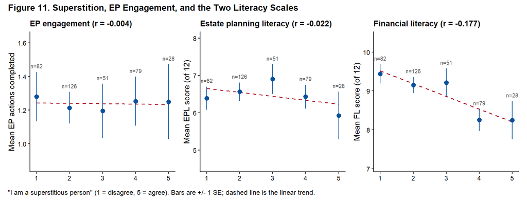

**Superstition is unrelated to estate planning engagement.** The correlation is -0.004 — essentially exactly zero — and the group means are flat across all five levels. If the hypothesis was that superstitious people avoid estate planning because it means contemplating death, these data give it no support at all.

It may be related to estate planning **literacy**, though in a non-linear way (it appears more inverted-U shaped). It also negatively relates to **financial literacy**; the association is negative and clearly non-zero (*r* = -0.177, *p* < .001).

## 9.3 Death Attitudes

The DAP-R (Wong, Reker & Gesser, 1994) is a 32-item, five-dimension measure of attitudes toward death, rated 1–7. The published structure includes the following facotrs: **Fear of Death**, **Death Avoidance**, **Neutral Acceptance**, **Approach Acceptance**, and **Escape Acceptance**. In this sample, the items from the scale generally reproduce the original structure. Expand the section below for additional details.

**NoteFactor analysis validation — click to expand**

Everything in this box is a check that the published DAP-R structure holds in this sample. It does. If you are only interested in how death attitudes relate to behaviour, skip past this box.

Note that the items here are **grouped by subscale** (`dapr_1`–`dapr_10` Approach Acceptance, `dapr_11`–`dapr_17` Fear of Death, `dapr_18`–`dapr_22` Death Avoidance, `dapr_23`–`dapr_27` Escape Acceptance, `dapr_28`–`dapr_32` Neutral Acceptance) rather than interleaved as in the published instrument, so the assignment below was read off the item wording. The full mapping is given first so it can be checked.

Table 37. DAP-R Item to Subscale Assignment

| Item | Subscale | Wording |
| --- | --- | --- |
| dapr_1 | Approach acceptance | Death brings a promise of a new and glorious life. |
| dapr_2 |  | I see death as a passage to an eternal and blessed place. |
| dapr_3 |  | Death is a union with God and eternal bliss. |
| dapr_4 |  | I look forward to a reunion with my loved ones after I die. |
| dapr_5 |  | One thing that gives me comfort in facing death is my belief in the afterlife. |
| dapr_6 |  | I believe that I will be in heaven after I die. |
| dapr_7 |  | I look forward to a life after death. |
| dapr_8 |  | Death is an entrance to a place of ultimate satisfaction. |
| dapr_9 |  | I believe that heaven will be a much better place than this world. |
| dapr_10 |  | Death offers a wonderful release of the soul. |
| dapr_11 | Fear of death | The uncertainty of not knowing what happens after death worries me. |
| dapr_12 |  | I have an intense fear of death. |
| dapr_13 |  | The fact that death will mean the end of everything as I know it frightens me. |
| dapr_14 |  | I am disturbed by the finality of death. |
| dapr_15 |  | The prospect of my own death arouses anxiety in me. |
| dapr_16 |  | The subject of life after death troubles me greatly. |
| dapr_17 |  | Death is no doubt a grim experience. |
| dapr_18 | Death avoidance | I avoid thinking about death altogether. |
| dapr_19 |  | I always try not to think about death. |
| dapr_20 |  | I try to have nothing to do with the subject of death. |
| dapr_21 |  | I avoid death thoughts at all cost. |
| dapr_22 |  | Whenever the thought of death enters my mind, I try to push it away. |
| dapr_23 | Escape acceptance | I see death as a relief from the burden of life. |
| dapr_24 |  | I view death as a relief from earthly suffering. |
| dapr_25 |  | Death provides an escape from this terrible world. |
| dapr_26 |  | Death is deliverance from pain and suffering. |
| dapr_27 |  | Death will bring an end to all my troubles. |
| dapr_28 | Neutral acceptance | Death is simply a part of the process of life. |
| dapr_29 |  | Death is a natural aspect of life. |
| dapr_30 |  | Death should be viewed as a natural, undeniable, and unavoidable event. |
| dapr_31 |  | Death is neither good nor bad. |
| dapr_32 |  | I would neither fear death nor welcome it. |

Table 38. DAP-R Subscale Reliabilities

| Subscale | k items | Alpha | Mean (SD) |
| --- | --- | --- | --- |
| Approach acceptance | 10 | 0.964 | 4.27 (1.73) |
| Fear of death | 7 | 0.918 | 3.74 (1.52) |
| Death avoidance | 5 | 0.929 | 3.80 (1.63) |
| Escape acceptance | 5 | 0.903 | 4.16 (1.57) |
| Neutral acceptance | 5 | 0.705 | 5.35 (0.94) |

Four of the five subscales are highly reliable. **Neutral acceptance is the weak one**, at alpha 0.70 — and it stays the weak one throughout what follows.

**How many factors?**

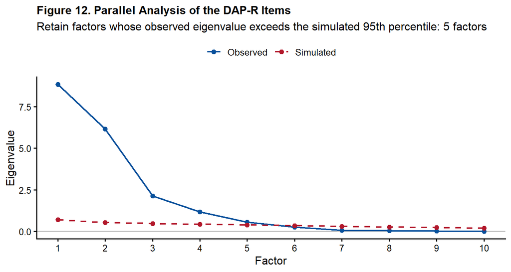

Parallel analysis retains **5 factors** — exactly the published number. The first five observed eigenvalues (8.85, 6.15, 2.12, 1.17, 0.55) all clear their simulated thresholds, and the sixth does not.

**Do the items land where they should?**

Table 39. Where Each Item's Primary Loading Falls (5-Factor EFA)

| Intended subscale | Approach acceptance | Death avoidance | Escape acceptance | Fear of death | Neutral acceptance |
| --- | --- | --- | --- | --- | --- |
| Approach acceptance | 10 | 0 | 0 | 0 | 0 |
| Death avoidance | 0 | 5 | 0 | 0 | 0 |
| Escape acceptance | 0 | 0 | 5 | 0 | 0 |
| Fear of death | 0 | 0 | 0 | 7 | 0 |
| Neutral acceptance | 1 | 0 | 0 | 1 | 3 |

Rows are the published subscale; columns are the empirical factor each item loaded on most strongly. A perfect recovery would put every item on the diagonal.

**30 of 32 items (94%) load most strongly on their intended factor.** The two exceptions are both Neutral Acceptance items: `dapr_31` (“Death is neither good nor bad”) and `dapr_32` (“I would neither fear death nor welcome it”), which drift toward Approach Acceptance and Fear of Death respectively, and weakly in both cases.

**Confirmatory fit**

Table 40. CFA of the DAP-R Structure

| Model | chi2 | df | CFI | TLI | RMSEA | SRMR |
| --- | --- | --- | --- | --- | --- | --- |
| One factor | 4647.9 | 464 | 0.444 | 0.405 | 0.174 | 0.224 |
| Five factors (published structure) | 980.0 | 454 | 0.932 | 0.926 | 0.061 | 0.062 |

MLR estimation on the 1-7 ratings; robust fit indices.

The five-factor model fits acceptably (CFI = 0.932, RMSEA = 0.061, SRMR = 0.062), and a one-factor model fails badly (CFI = 0.444). Standardized loadings average 0.79, with only 2 below .40 — again `dapr_31` and `dapr_32`.

Table 41. DAP-R Factor Correlations

|  | Approach acceptance | Fear of death | Death avoidance | Escape acceptance | Neutral acceptance |
| --- | --- | --- | --- | --- | --- |
| Approach acceptance | 1.00 | -0.09 | -0.06 | 0.53 | 0.14 |
| Fear of death | -0.09 | 1.00 | 0.70 | 0.03 | -0.21 |
| Death avoidance | -0.06 | 0.70 | 1.00 | -0.08 | -0.15 |
| Escape acceptance | 0.53 | 0.03 | -0.08 | 1.00 | 0.23 |
| Neutral acceptance | 0.14 | -0.21 | -0.15 | 0.23 | 1.00 |

The correlations reproduce the pattern reported in the original validation: **Fear of Death and Death Avoidance are strongly related** (*r* = 0.70) — both are negative orientations toward death — and **Approach and Escape Acceptance go together** (*r* = 0.53), since both frame death as desirable. Neutral Acceptance stands largely apart from the rest, as it should: regarding death as an ordinary fact is not the same as welcoming or dreading it.

**Verdict: the published structure replicates.**

Parallel analysis recovers exactly five factors, 94% of items load on their intended subscale, the five-factor CFA fits acceptably while a one-factor model does not, and the factor intercorrelations reproduce the expected pattern.

The one qualification is **Neutral Acceptance**, which is the weakest subscale on every diagnostic: the lowest alpha, both of the misplaced items, and both of the sub-.40 loadings. Dropping `dapr_31` and `dapr_32` raises CFI to 0.945. This is a known soft spot in the DAP-R rather than a problem with this sample.

The various DAP-R factors correlate to prior EP engagement, behavioral intentions, and behavioral expectations in different ways.

Table 42. Death Attitudes, Superstition, and the Three Behavioural Measures

| Measure | Mean (SD) | EP engagement | Intentions | Expectations |
| --- | --- | --- | --- | --- |
| Fear of death | 3.74 (1.52) | -0.110* | +0.091 | +0.201** |
| Death avoidance | 3.80 (1.63) | -0.083 | +0.112* | +0.143** |
| Neutral acceptance | 5.35 (0.94) | +0.141** | +0.007 | -0.009 |
| Approach acceptance | 4.27 (1.73) | +0.135** | +0.193** | +0.204** |
| Escape acceptance | 4.16 (1.57) | +0.064 | +0.093 | +0.063 |
| Superstition | 2.58 (1.26) | -0.004 | +0.077 | +0.182** |

* p < .05, ** p < .01. DAP-R subscales are means of 1-7 ratings; superstition is a single 1-5 item excluding the 6 participants coded 6. EP engagement is the count of estate planning actions already completed.

**Some patterns worth noting.**

**Attitudes line up sensibly with what people have actually done.** Fear of death (-0.110) and death avoidance (-0.083) go with *less* completed estate planning; approach acceptance (+0.135) and neutral acceptance (+0.141) go with *more*. Being able to contemplate death calmly is associated with having done the paperwork; avoiding the thought is associated with not having.

**But these attitudes do not line up with what people say they will do in the near future.** Nearly every measure correlates positively with intentions and expectations — including fear of death and and death avoidance.

**Superstition is unrelated to prior estate planning engagement.** Its correlation with completed actions is -0.004 — flat across all five levels (Figure 11). It relates only to expectations (+0.182) and, as shown earlier, to financial literacy.

**NoteHow to read this**

Two cautions. First, all of these correlations are small — the largest is about 0.20, so death attitudes may only be a minor part of the picture.

This is exploratory. The measures were collected for descriptive purposes, nothing here was planned in advance, and none of it should be reported as a test of a hypothesis.

# 10 Conclusions

Table 43. Summary of Findings

| Question | Answer | Evidence |
| --- | --- | --- |
| Q1: Is EPL distinguishable from FL? | Yes | Two-factor beats one-factor, chi2(1) = 33.6, p < .001. |
| Q1: Are EPL's two dimensions distinguishable? | Yes | Three-factor beats two-factor, chi2(2) = 20.7, p < .001; also beats both alternative merges. |
| Q2: How much variance is general rather than block-specific? | Most of it | Bifactor ECV = 0.66; omega-HS = 0.32 (FL) and 0.31 (EPL-Legal); EPL-Fin specific factor not estimable. |
| Is EP engagement related to EPL net of FL? | Yes | r = 0.27 zero-order; partial r = 0.22 holding FL constant (p < .001). |
| Is EP engagement related to FL net of EPL? | No | Partial r = 0.03 holding EPL constant (p = 0.59) - indistinguishable from zero. |
| Should FL / EPL subscores be reported? | Total scale yes, subscores no | omega-H / omega = 0.83 of reliable total-score variance is general; subscale alphas 0.73 / 0.66 / 0.60. |

**What to claim.** Estate planning literacy is empirically distinguishable from financial literacy, its two dimensions are distinguishable from each other, and — the part that matters — estate planning engagement is associated with EPL *over and above* financial literacy, while the reverse association is indistinguishable from zero.

**What not to claim.** That these are independent abilities. They share most of their variance, and the EPL-Fin block has no identifiable unique variance at all.

## 10.1 Are the Items Good Enough?

Overall, the **items are psychometrically sound but the EPL-Fin subscale is not**.

**The items themselves behave well.** All 24 loadings fall between 0.38 and 0.79, no item is at floor or ceiling, and total-scale alpha is 0.82. This is not a set of broken items.

**The overlap between factors is probably real, not an artifact.** One plausible artifact was scoring “I don’t know” as incorrect: someone who skips a lot scores low on everything, which could manufacture a general factor. It does not. Refitting the two-factor model with blanks treated as genuinely **missing** rather than wrong *raises* the FL–EPL latent correlation from 0.74 to about .82. Restricting attention to items people actually attempted makes the constructs look **more** alike, not less.

**The potential weak point is EPL-Fin.** The three items have a Cronbach’s alpha of 0.60, a correlation of 0.77 with financial literacy, a second-order loading of 0.94, and — the decisive finding — no estimable specific factor once the general factor is removed.

**Suggestions for the next wave (this is what Claude - not necessarily I - recommends).**

- **Rebuild EPL-Fin around knowledge, not arithmetic.** Items on step-up in basis, estate tax thresholds, creditor priority, or required distributions for inherited retirement accounts have answers you cannot derive from first principles. As a screening test: if a numerate participant with no estate planning experience can reason to the answer, it is measuring numeracy.
- **Expand it.** Three indicators is the identification minimum and leaves no room to detect problems. Eight to ten would make the EPL-Fin dimension testable rather than fragile.
- **Keep the legal/administrative items.** They are the strongest part of the instrument: lowest correlation with FL (0.63), the strongest association with EP engagement net of financial literacy (Section 8.2), and content that genuinely requires knowing a legal default rather than computing one.
- **Design in a discriminant criterion.** Recruit a known-groups sample — people who have completed estate planning, or professionals — and check that EPL separates them while FL does not. That is a stronger test of the construct than any factor model.
- **Consider separating knowledge from confidence.** Treating blanks as wrong conflates “does not know” with “knows and is wrong.” Capturing confidence alongside each answer would let you model them separately.